# Презентация по лабораторной работе №3

Дисциплина: Компьютерный практикум по статистическому анализу данных

Лобанова П.И.

Российский университет дружбы народов, Москва, Россия

29 сентября 2025

# Информация

## Докладчик

- Лобанова Полина Иннокентьевна
- Учащаяся на направлении “Фундаментальная информатика и информационные технологии”
- Студентка группы НФИбд-02-22
- polla-2004@mail.ru

# Цель

Основная цель работы — освоить применение циклов функций и сторонних для Julia пакетов для решения задач линейной алгебры и работы с матрицами.

# Задание

1. Используя Jupyter Lab, повторите примеры из раздела 3.2.
2. Выполните задания для самостоятельной работы (раздел 3.4).

# Выполнение

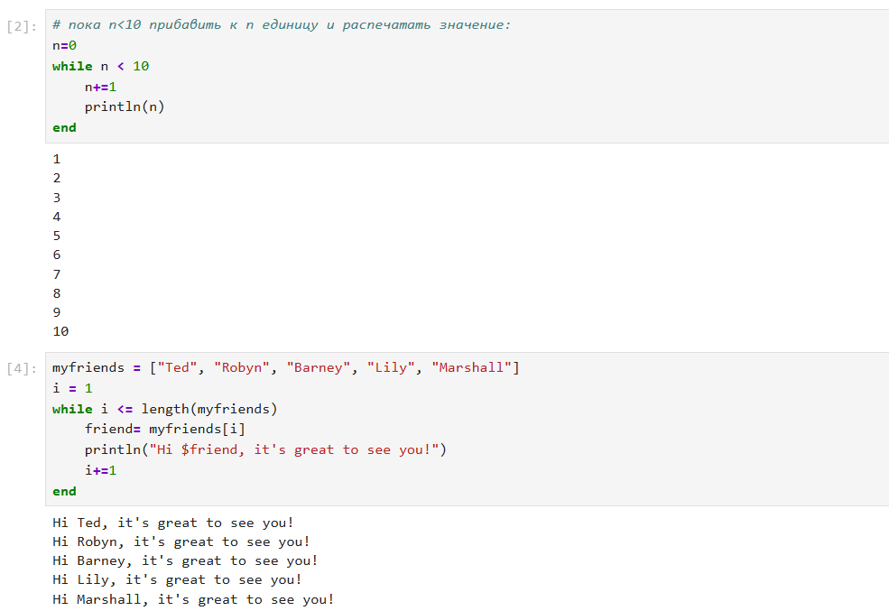

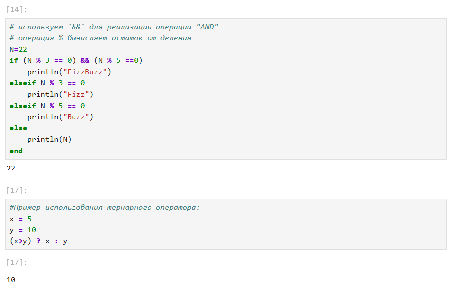

*Примеры с условными выражениями*

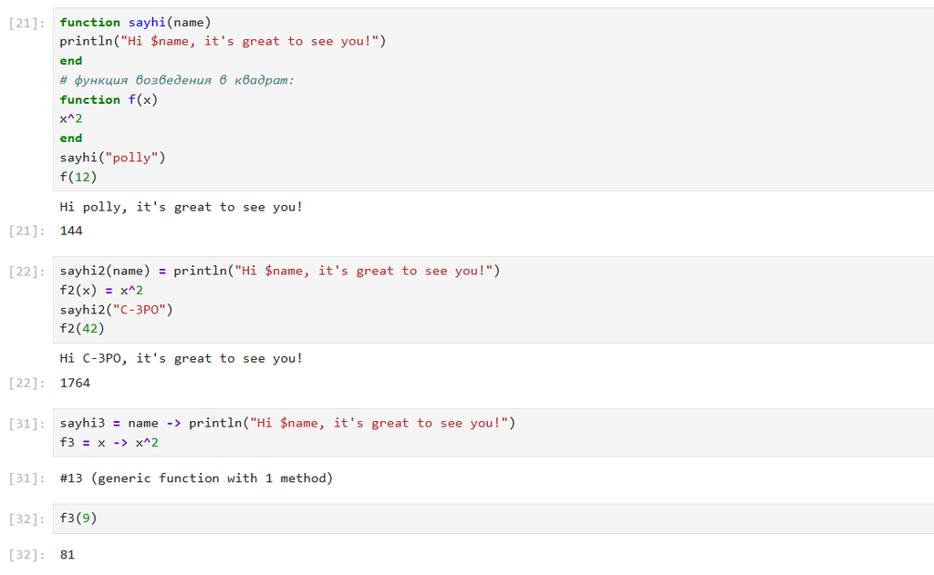

*Примеры с функциями*

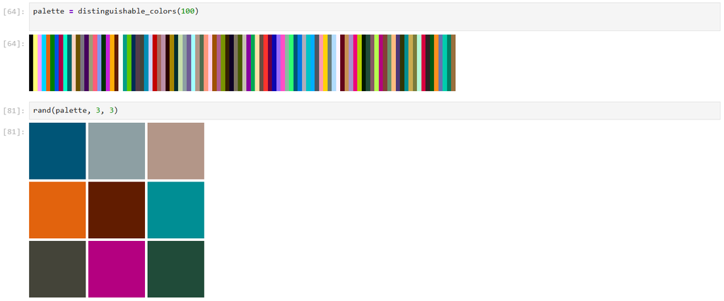

*Примеры с сторонними библиотеками*

– вывела на экран целые числа от 1 до 100 и напечатала их квадраты;

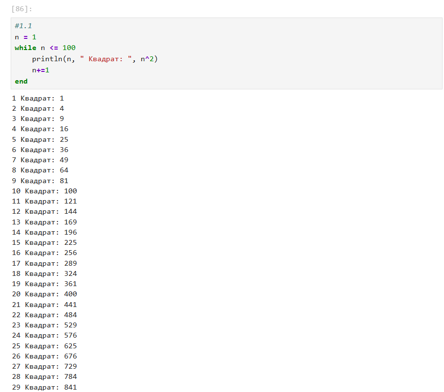

*Задание 1.1*

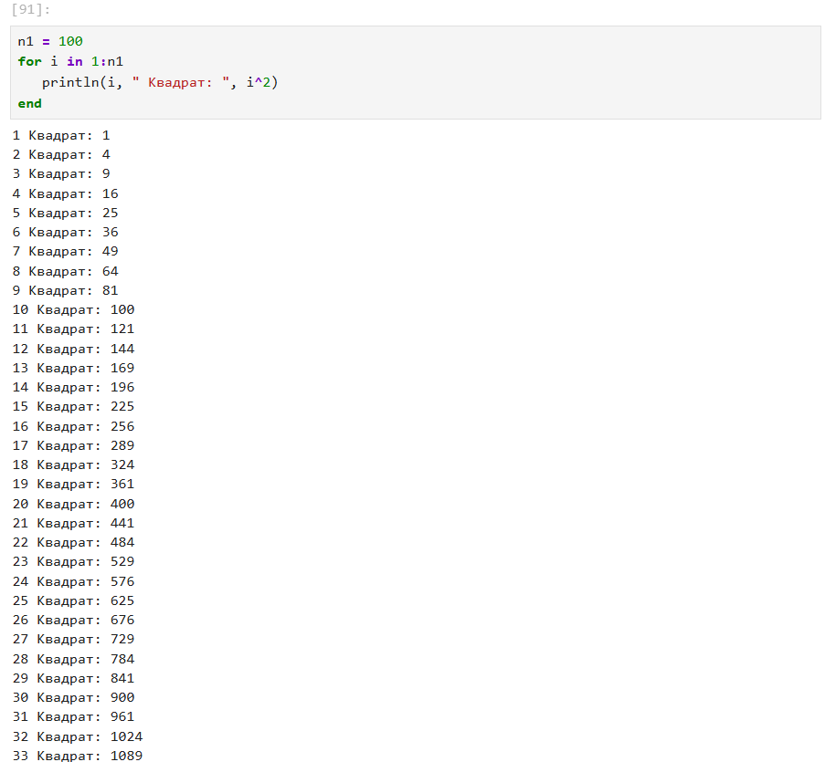

*Задание 1.1*

– создала словарь squares, который будет содержать целые числа в качестве ключей и квадраты в качестве их пар-значений;

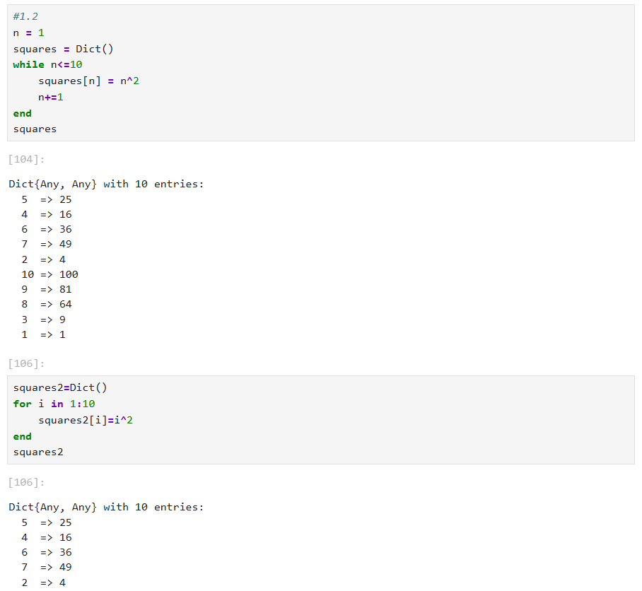

*Задание 1.2*

– создала массив squares_arr, содержащий квадраты всех чисел от 1 до 100.

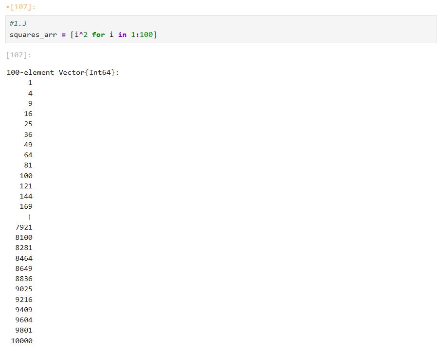

*Задание 1.3*

Написала условный оператор, который печатает число, если число чётное, и строку «нечётное», если число нечётное. Переписала код, используя тернарный оператор.

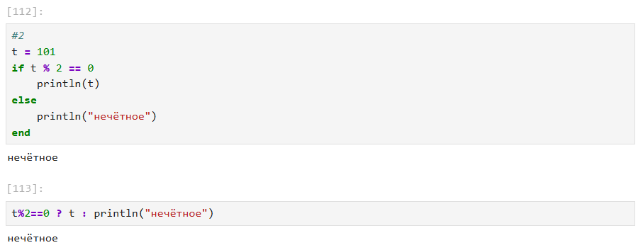

*Задание 2*

Написала функцию add_one, которая добавляет 1 к своему входу.

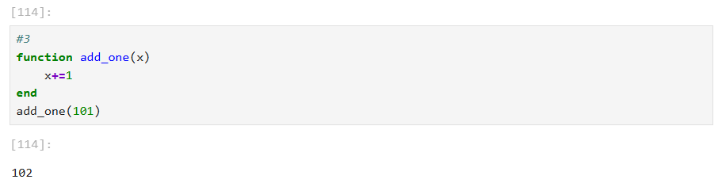

*Задание 3*

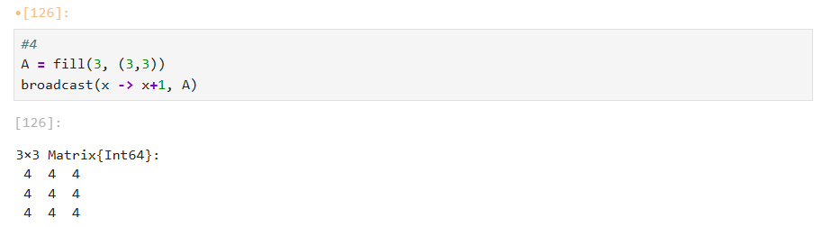

*Задание 4*

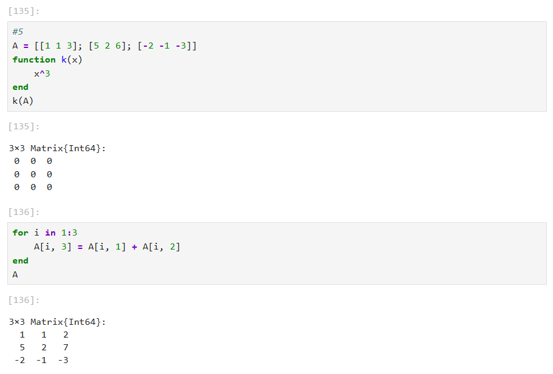

*Задание 5*

Создала матрицу B с элементами B_i1 = 10, B_i2 = −10, B_i3 = 10, i = 1, 2, … , 15. Вычислила матрицу C = B^T B.

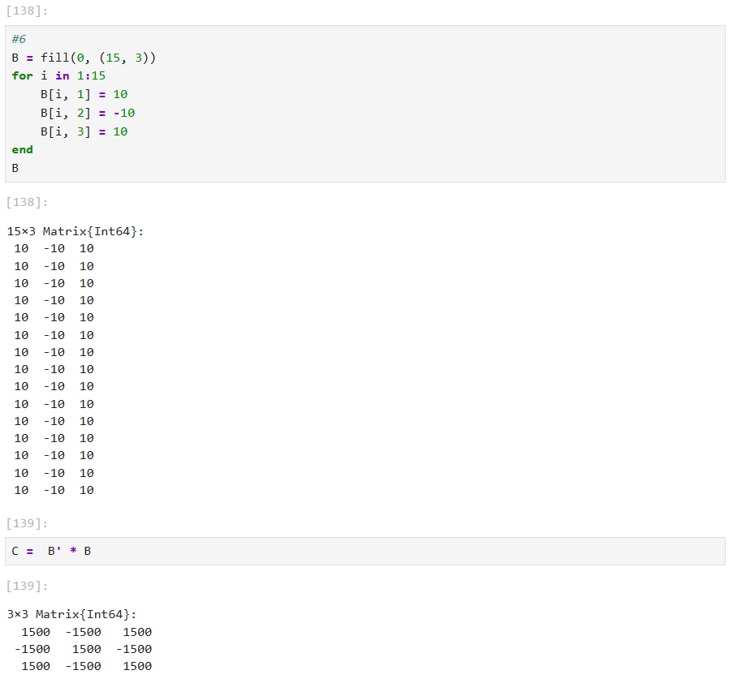

*Задание 6*

[figure not shown]

*Задание 7.1*

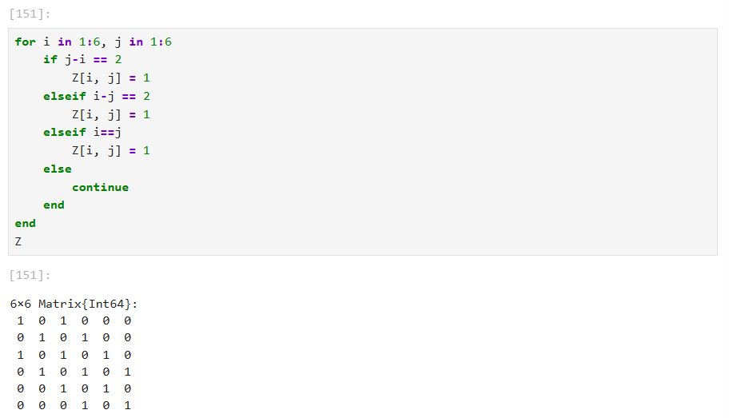

*Задание 7.2*

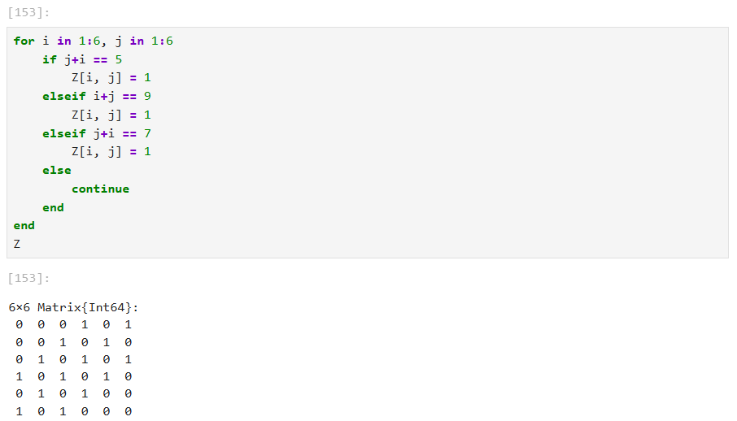

*Задание 7.3*

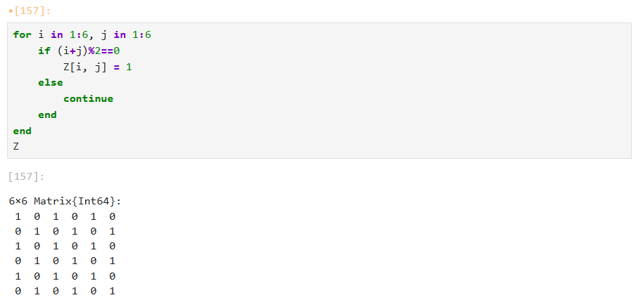

*Задание 7.4*

– Написала свою функцию, аналогичную функции outer() языка R.

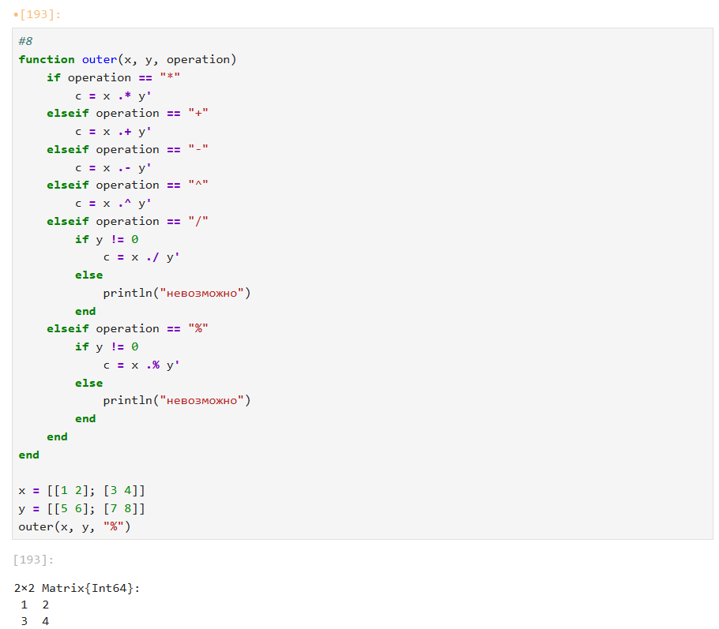

*Задание 8.1*

– Используя написанную функцию outer(), создала матрицы следующей структуры:

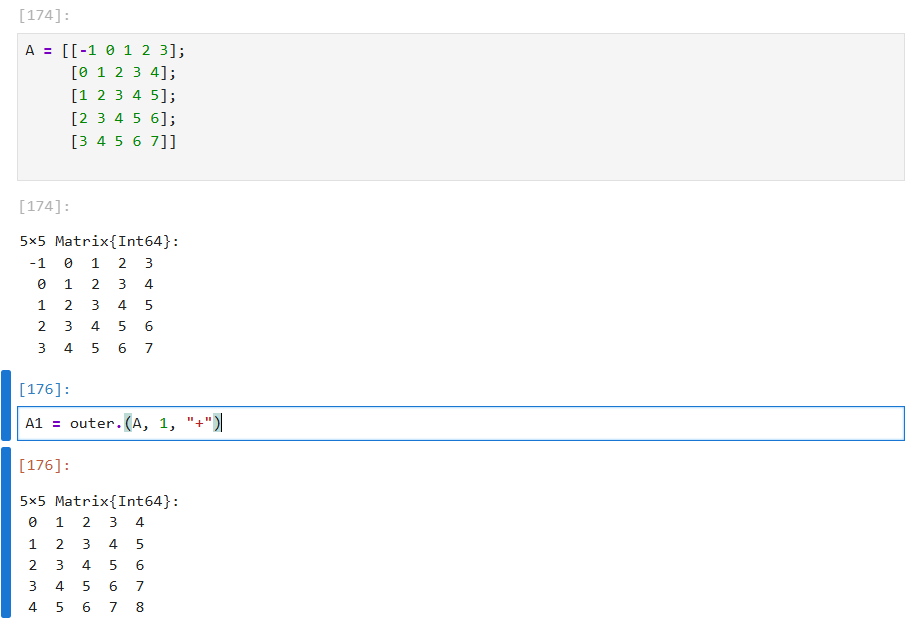

*Задание 8.2*

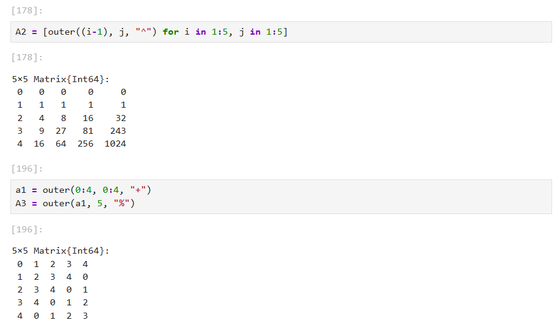

*Задание 8.3*

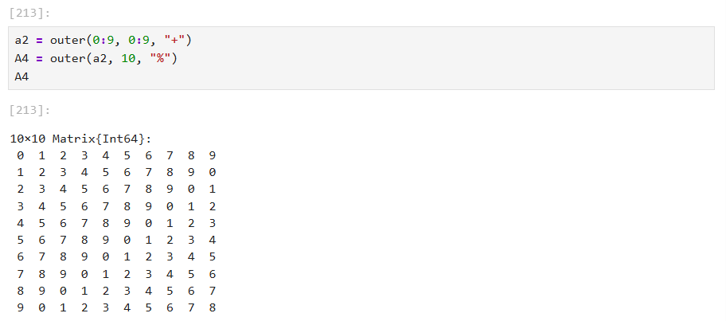

*Задание 8.4*

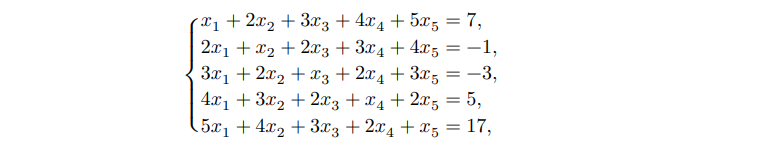

*Задача*

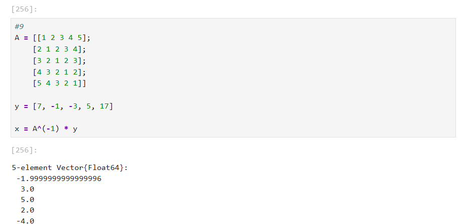

*Задание 9*

– Нашла число элементов в каждой строке матрицы M, которые больше числа N (например, N = 4).

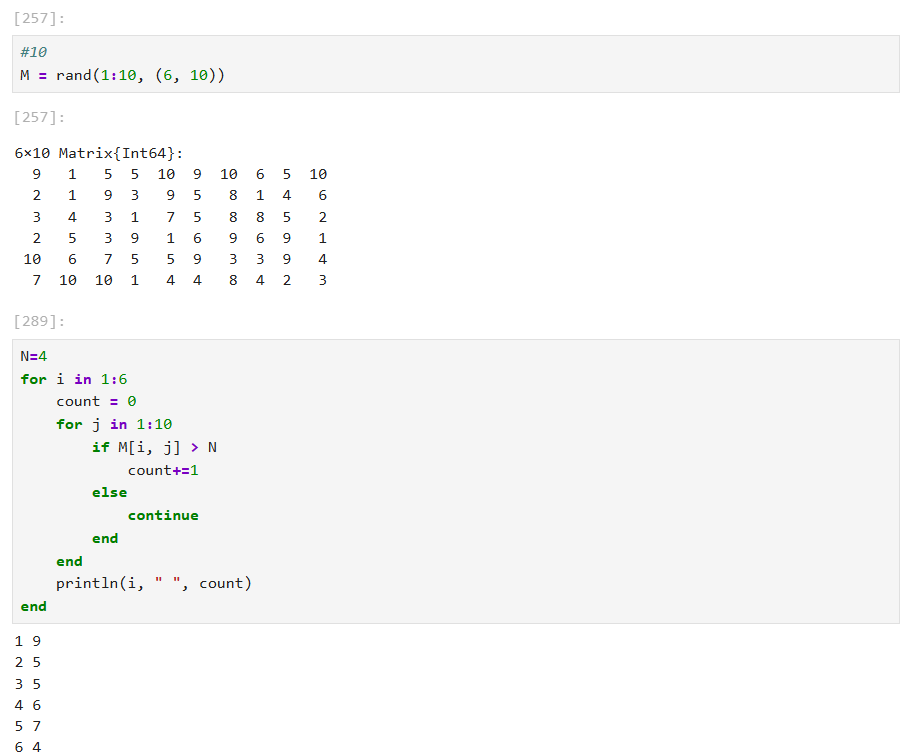

*Задание 10.1*

– Определила, в каких строках матрицы M число M1 (например, M1 = 10) встречается ровно 2 раза.

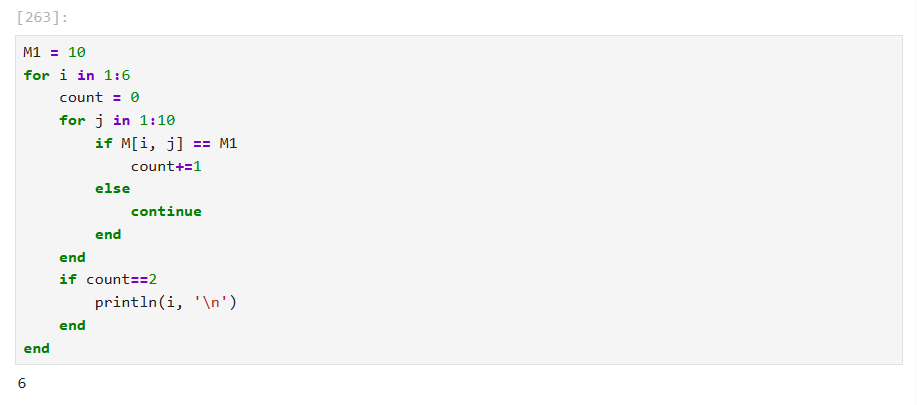

*Задание 10.2*

– Определила все пары столбцов матрицы M, сумма элементов которых больше K (например, K = 75).

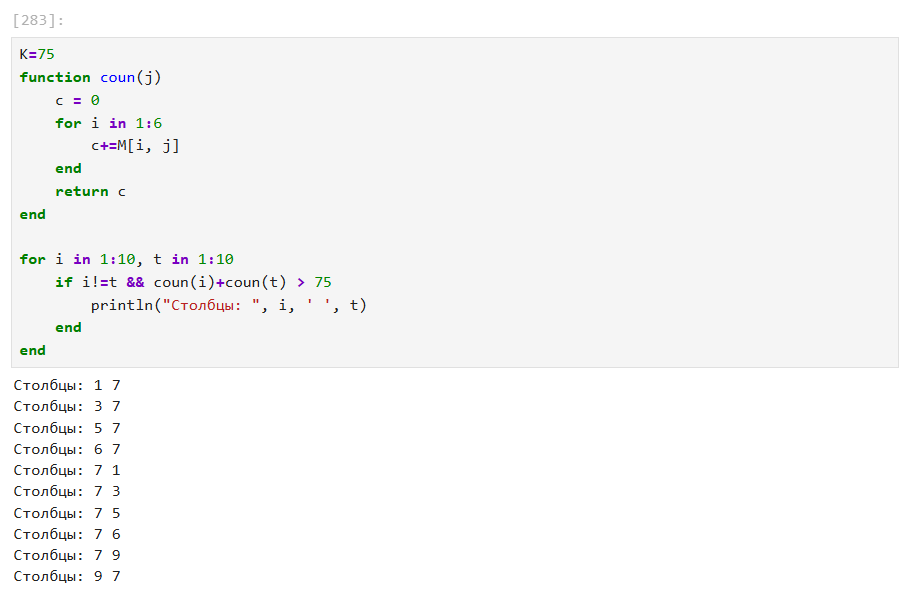

*Задание 10.3*

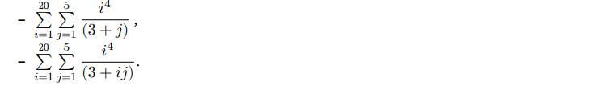

*Задача*

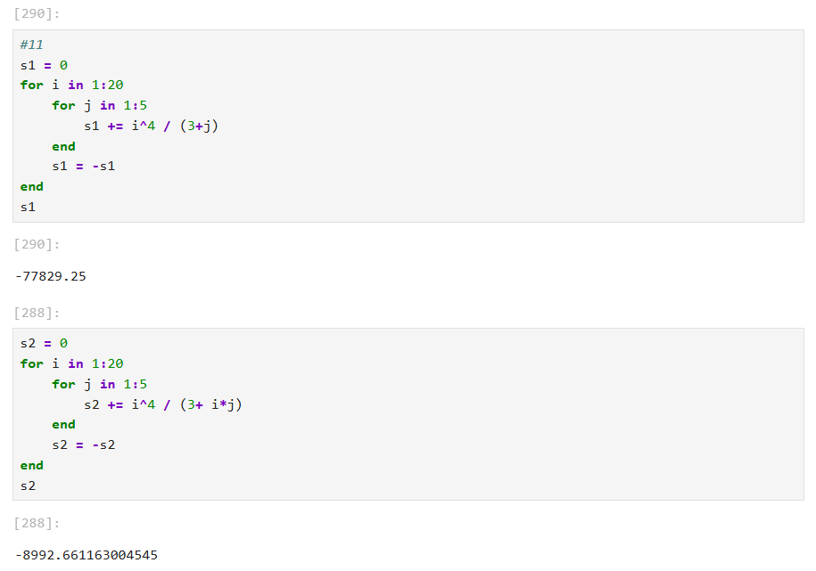

*Задание 11*

# Вывод

Я освоила применение циклов функций и сторонних для Julia пакетов для решения задач линейной алгебры и работы с матрицами.